### Predicting Daily DC Bike Share Ridership with **prophet**

This markdown documents multiple attempts to forecast daily ridership of the DC Bike Share program using Facebook’s forecasting package [prophet](https://facebook.github.io/prophet/docs/quick_start.html#r-api). Data was gathered from the official DC Bike Share [site](https://s3.amazonaws.com/capitalbikeshare-data/index.html) and spans daily bike trips logged from Sept 15th, 2010 to Sept 30th, 2018.

### Visualization

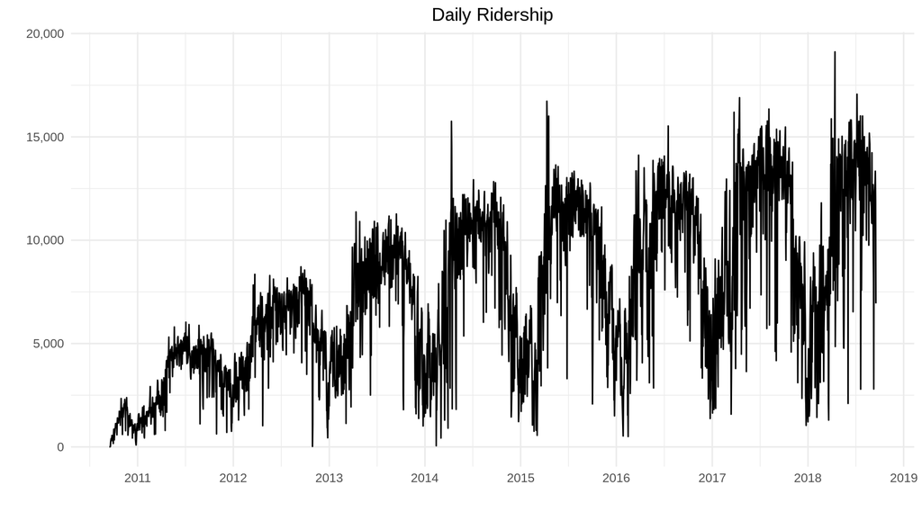

### Removing Outliers

Since there appear to be multiple outliers in the dataset and the prophet package can handle missing data points, we’ll remove some outliers before proceeding to modeling the data.

*Identifying and processing outliers*

One way to identify outliers is to use [moving-median decomposition](https://anomaly.io/anomaly-detection-moving-median-decomposition/). In the case below, a two-week-long running median trend is subtracted from the original series. Next, observations which fall outside of 4 standard deviations of that running median trend are isolated and removed from the series for future modeling.

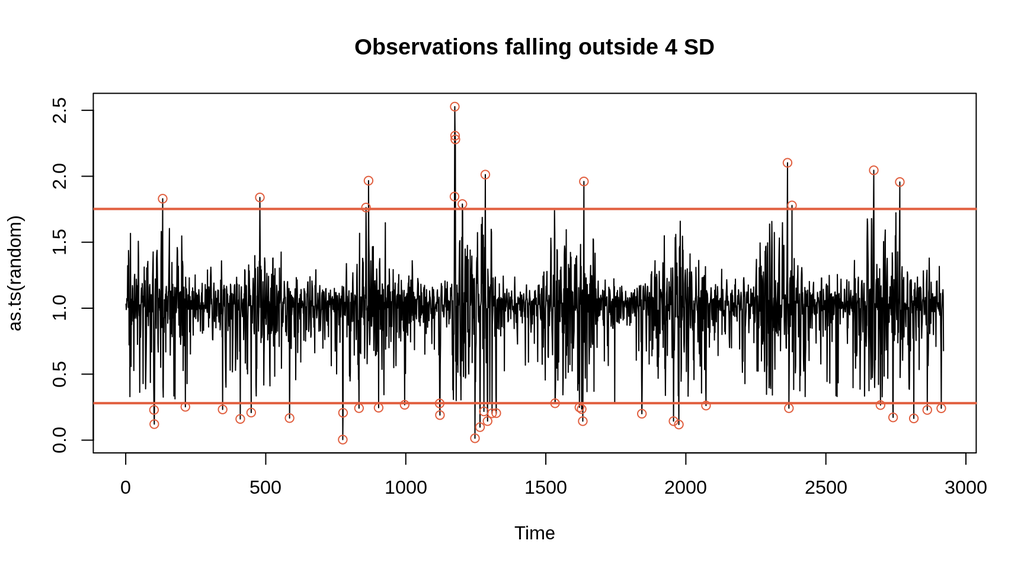

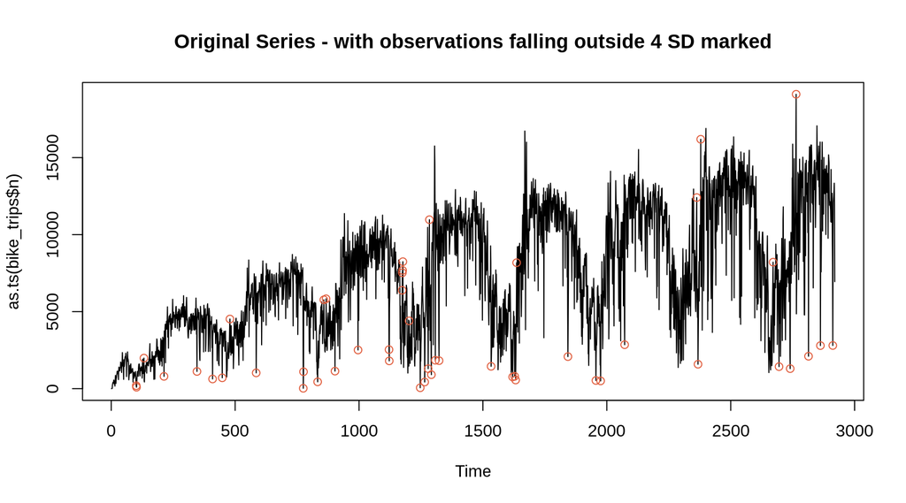

### First Prophet model

Due to the complexity inherent in daily forecasting, the modeling will be done with Facebook’s semi-automated [prophet](https://facebook.github.io/prophet/docs/quick_start.html#r-api) package which can account for multiple seasonalities.

First Prophet Prediction

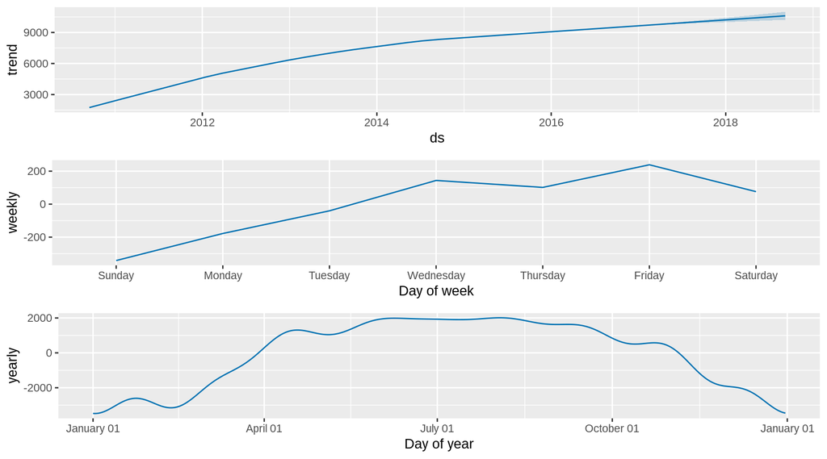

```r
# https://facebook.github.io/prophet/docs/quick_start.html#r-api

## Prophet Forecast 1

  # Training
  prophetFit1 <- prophet(train,
                         yearly.seasonality = T,
                         weekly.seasonality = T,
                         daily.seasonality = F)

  # Creating dataframe for future forecast
  future <- make_future_dataframe(prophetFit1, periods = nrow(test))

  # Predicting
  prophetForecast1 <- predict(prophetFit1, future)

  # The resulting prophetForecast1 dataframe contains columns for predictions, trend data, and uncertainty intervals

  # Visualizing ts components - trend, weekly and yearly seasonalities
  prophet_plot_components(prophetFit1, prophetForecast1)
```

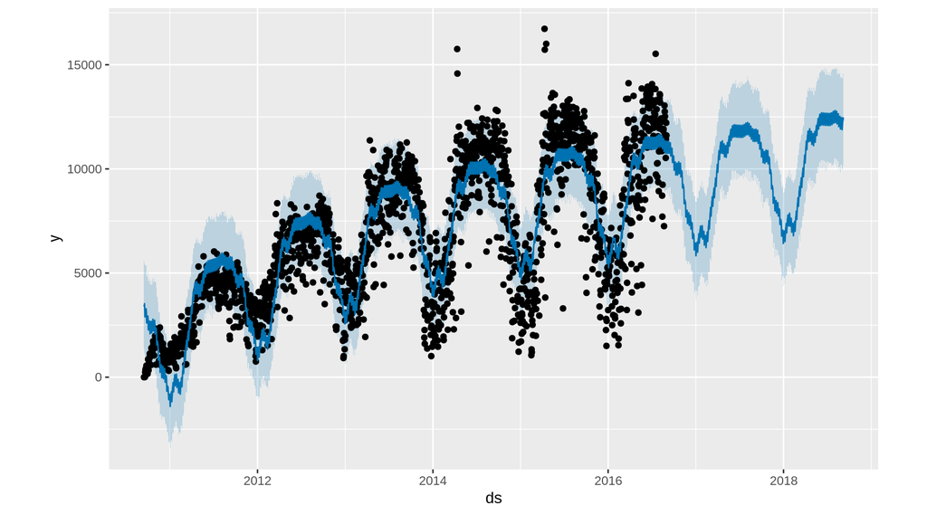

```r
  # Visualize forecast
  plot(prophetFit1, prophetForecast1)
```

Using a dynamic visualiztion, we can zoom in on the series daily observations and see how much volatility exists on a day-to-day basis. We also can see locate extremely large observations during the second week of April in 2014 and 2015.

[interactive chart not shown]

Evaluation of the first prediction:

```
##     Min.  1st Qu.   Median     Mean  3rd Qu.     Max.
## -621.427  -16.520    4.789  -14.968   15.360   47.239
```

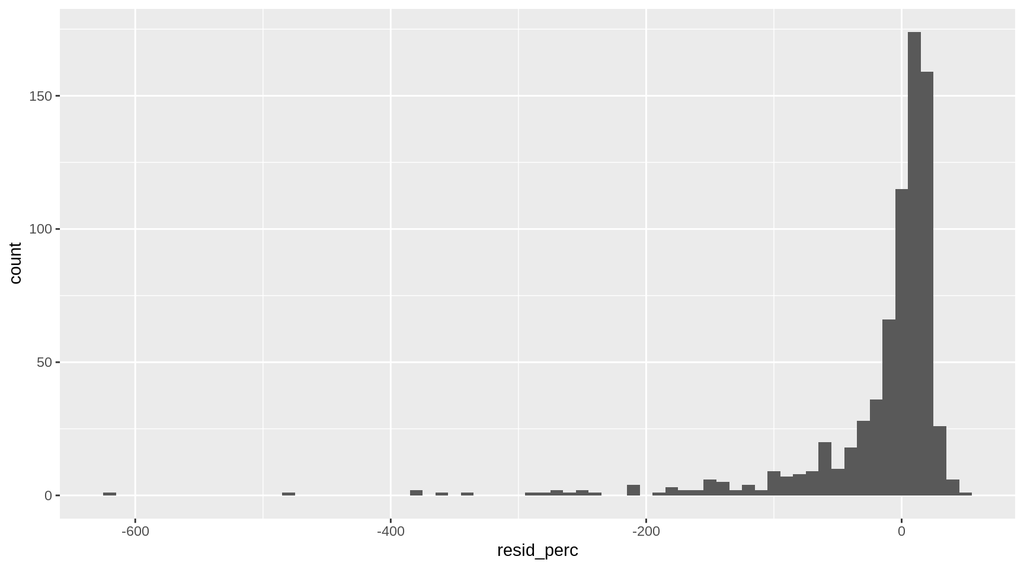

### Second Prophet model

Given that the overal trend appears to be leveling off, we’ll try a second modeling approach with a logistic growth specified and a carrying capacity.

A *carry capacity* refers to the maxium possible value for the series. In this case, we’ll set it at 17500

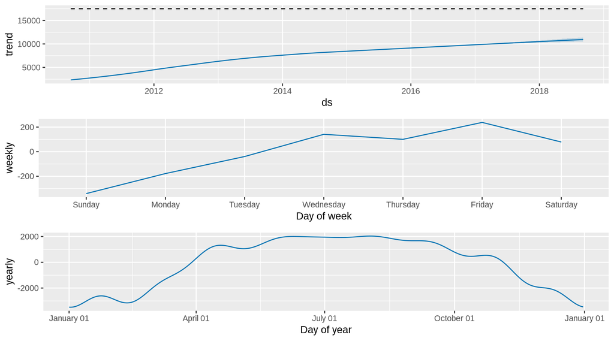

```r
# https://facebook.github.io/prophet/docs/quick_start.html#r-api

## Prophet Forecast 1

  # Training

  train$cap <- 17500

  prophetFit1 <- prophet(train,
                         yearly.seasonality = T,
                         weekly.seasonality = T,
                         daily.seasonality = F,
                         growth = "logistic")

  # Creating dataframe for future forecast
  future <- make_future_dataframe(prophetFit1, periods = nrow(test))
  future$cap <- 17500


  # Predicting
  prophetForecast1 <- predict(prophetFit1, future)

  # The resulting prophetForecast1 dataframe contains columns for predictions, trend data, and uncertainty intervals

  # Visualizing ts components - trend, weekly and yearly seasonalities
  prophet_plot_components(prophetFit1, prophetForecast1)
```

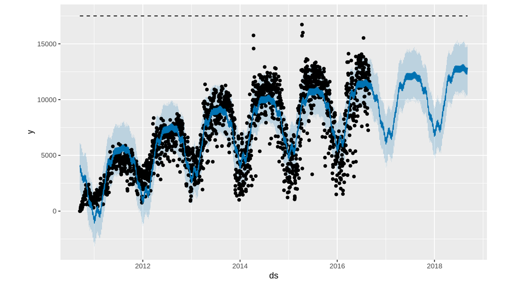

```r
  # Visualize forecast
  plot(prophetFit1, prophetForecast1)
```

```r
  # Dynamic Plot of forecast
  dyplot.prophet(prophetFit1, prophetForecast1)
```

[interactive chart not shown]

Evaluation of the second prediction:

```
##     Min.  1st Qu.   Median     Mean  3rd Qu.     Max.
## -647.681  -20.323    2.242  -18.024   13.503   45.660
```

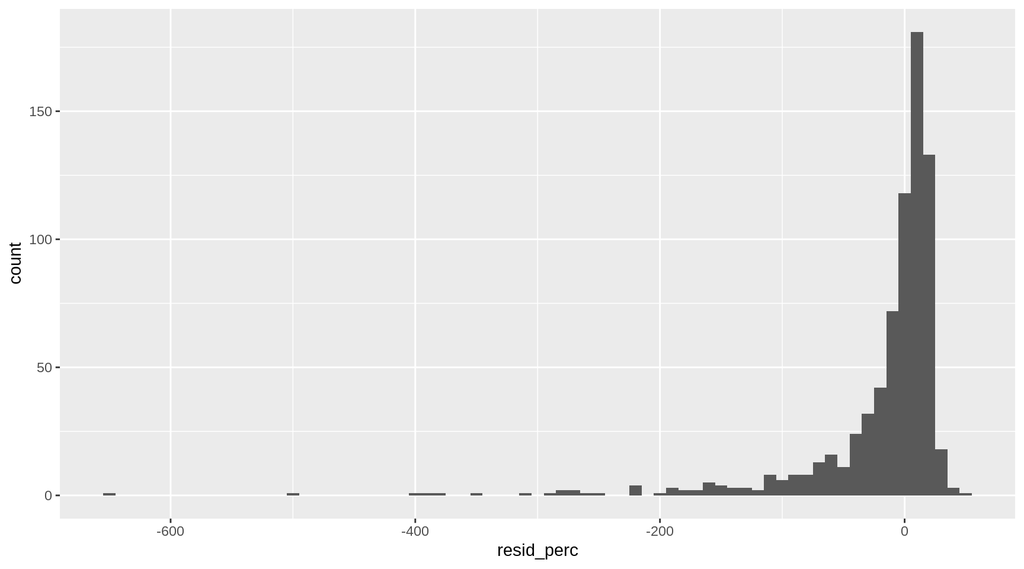

### Next Steps

- Make use of prophet’s holiday feature which allows for certain observations to be marked as influential in establishing change points in the trend.
- Tuning the parameters related to the flexibility that we want to give the model to fit change points, seasonality and holidays.